# pRecipe| Precipitation R Recipes

Mijael Rodrigo Vargas Godoy, Yannis Markonis

2022-10-13

`pRecipe` was conceived back in 2019 as part of MRVG’s doctoral dissertation at the Faculty of Environmental Sciences, Czech University of Life Sciences Prague, Czech Republic. Designed with reproducible science **`pRecipe` facilitates the download, exploration, visualization, and analysis** of multiple precipitation data products across various spatiotemporal scales.

~*The Global Water Cycle Budget* | Vargas Godoy et al. (2021)

*“Like civilization and technology, our understanding of the global water cycle has been continuously evolving, and we have adapted our quantification methods to better exploit new technological resources. The accurate quantification of global water fluxes and storage is crucial in studying the global water cycle.”*

## Before We Start

Like many other R packages, `pRecipe` has some system requirements:

- [PROJ](https://proj.org/download.html)
- Geospatial Data Abstraction Library [(GDAL)](https://gdal.org/download.html)
- Network Common Data Form [(NetCDF)](https://www.unidata.ucar.edu/software/netcdf/)
- Climate Data Operators [(CDO)](https://code.mpimet.mpg.de/projects/cdo)

## Data

`pRecipe` database hosts 24 different precipitation data sets; seven gauge-based, eight satellite-based, five reanalysis, and four hydrological model precipitation products. Their native specifications, as well as links to their providers, and their respective references are detailed in the following subsections. We have already homogenized, compacted to a single file, and stored them in a [Zenodo repository](https://zenodo.org/record/7094293) under the following naming convention:

`<data set>_<variable>_<units>_<coverage>_<start date>_<end date>_<resolution>_<time step>.nc`

The `pRecipe` data collection was homogenized to these specifications:

- `<variable>` = total precipitation (tp)
- `<units>` = millimeters (mm)
- `<resolution>` = 0.25$^\circ$
- `<time step>` = monthly

E.g., GPCP v2.3 (Adler et al. 2003) would be:

`gpcp_tp_mm_global_197901_202205_025_monthly.nc`

### Gauge-Based Products

| Data Set | Spatial Resolution | Temporal Resolution | Record Length | Get Data | Reference |
| --- | --- | --- | --- | --- | --- |
| CRU TS v4.06 | 0.5$^\circ$ | Monthly | 1901-01 to 2021-12 | [Download](https://crudata.uea.ac.uk/cru/data/hrg/) | Harris et al. (2020) |
| CPC-Global | 0.5$^\circ$ | Daily | 1979-01 to 2022-08 | [Download](https://psl.noaa.gov/data/gridded/data.cpc.globalprecip.html) | P. Xie, Chen, and Shi (2010) |
| EM-EARTH | 0.1$^\circ$ | Daily | 1950-01 to 2019-12 | [Download](https://www.frdr-dfdr.ca/repo/dataset/8d30ab02-f2bd-4d05-ae43-11f4a387e5ad) | Tang, Clark, and Papalexiou (2022) |
| GHCN v2 | 5$^\circ$ | Monthly | 1900-01 to 2015-05 | [Download](https://psl.noaa.gov/data/gridded/data.ghcngridded.html) | Peterson and Vose (1997) |
| GPCC v2020 | 0.25$^\circ$ | Monthly | 1891-01 to 2022-08 | [Download](https://psl.noaa.gov/data/gridded/data.gpcc.html) | Schneider et al. (2011) |
| PRECL/L | 0.5$^\circ$ | Monthly | 1948-01 to 2022-08 | [Download](https://psl.noaa.gov/data/gridded/data.precl.html) | Chen et al. (2002) |
| UDel v5.01 | 0.5$^\circ$ | Monthly | 1901-01 to 2017-12 | [Download](https://psl.noaa.gov/data/gridded/data.UDel_AirT_Precip.html) | Willmott and Matsuura (2001) |

### Satellite-Based Products

| Data Set | Spatial Resolution | Temporal Resolution | Record Length | Get Data | Reference |
| --- | --- | --- | --- | --- | --- |
| CHIRPS v2.0 | 0.05$^\circ$ | Monthly | 1981-01 to 2022-07 | [Download](https://www.chc.ucsb.edu/data/chirps) | Funk et al. (2015) |
| CMAP | 2.5$^\circ$ | Monthly | 1979-01 to 2022-07 | [Download](https://psl.noaa.gov/data/gridded/data.cmap.html) | Pingping Xie and Arkin (1997) |
| CMORPH | 0.25$^\circ$ | Daily | 1998-01 to 2021-12 | [Download](https://www.ncei.noaa.gov/data/cmorph-high-resolution-global-precipitation-estimates/) | Joyce et al. (2004) |
| GPCP v2.3 | 0.5$^\circ$ | Monthly | 1979-01 to 2022-05 | [Download](https://psl.noaa.gov/data/gridded/data.gpcp.html) | Adler et al. (2003) |
| GPM IMERGM v06 | 0.1$^\circ$ | Monthly | 2000-06 to 2020-12 | [Download](https://doi.org/10.5067/GPM/IMERG/3B-MONTH/06) | G. J. Huffman et al. (2019) |
| MSWEP v2.8 | 0.1$^\circ$ | Monthly | 1979-02 to 2022-06 | [Download](http://www.gloh2o.org/mswep/) | Beck et al. (2019) |
| PERSIANN-CDR | 0.25$^\circ$ | Monthly | 1983-01 to 2022-06 | [Download](https://chrsdata.eng.uci.edu/) | Ashouri et al. (2015) |
| TRMM 3B43 v7 | 0.25$^\circ$ | Monthly | 1998-01 to 2019-12 | [Download](https://doi.org/10.5067/TRMM/TMPA/MONTH/7) | George J. Huffman et al. (2010) |

### Reanalysis Products

| Data Set | Spatial Resolution | Temporal Resolution | Record Length | Get Data | Reference |
| --- | --- | --- | --- | --- | --- |
| 20CR v3 | 1$^\circ$ | Monthly | 1836-01 to 2015-12 | [Download](https://psl.noaa.gov/data/gridded/data.20thC_ReanV3.html) | Slivinski et al. (2019) |
| ERA-20C | 1.125$^\circ$ | Monthly | 1900-01 to 2010-12 | [Download](https://www.ecmwf.int/en/forecasts/datasets/reanalysis-datasets/era-20c) | Poli et al. (2016) |
| ERA5 | 0.25$^\circ$ | Monthly | 1959-01 to 2021-12 | [Download](https://www.ecmwf.int/en/forecasts/datasets/reanalysis-datasets/era5) | Hersbach et al. (2020) |
| NCEP/NCAR R1 | 1.875$^\circ$ | Monthly | 1948-01 to 2022-08 | [Download](https://psl.noaa.gov/data/gridded/data.ncep.reanalysis.derived.html) | Kalnay et al. (1996) |
| NCEP/DOE R2 | 1.875$^\circ$ | Monthly | 1979-01 to 2022-08 | [Download](https://psl.noaa.gov/data/gridded/data.ncep.reanalysis2.html) | Kanamitsu et al. (2002) |

### Hydrological Model Forcing

| Data Set | Spatial Resolution | Temporal Resolution | Record Length | Get Data | Reference |
| --- | --- | --- | --- | --- | --- |
| GLDAS CLSM v2.0 | 0.25$^\circ$ | Daily | 1948-01 to 2014-12 | [Download](https://ldas.gsfc.nasa.gov/gldas/gldas-get-data) | Rodell et al. (2004) |
| GLDAS NOAH v2.0 | 0.25$^\circ$ | Monthly | 1948-01 to 2014-12 | [Download](https://ldas.gsfc.nasa.gov/gldas/gldas-get-data) | Rodell et al. (2004) |
| GLDAS VIC v2.0 | 1$^\circ$ | Monthly | 1948-01 to 2014-12 | [Download](https://ldas.gsfc.nasa.gov/gldas/gldas-get-data) | Rodell et al. (2004) |
| TerraClimate | 4$km$ | Monthly | 1958-01 to 2021-12 | [Download](https://www.climatologylab.org/terraclimate.html) | Abatzoglou et al. (2018) |

# Recipe

In this introductory recipe we will first download the ERA5 data set. We will then subset the downloaded data over Central Europe for the 1981-2020 period, and crop it to the national scale for Czech Republic. In the next step, we will generate time series for our data sets and conclude with the visualization of our data.

**NOTE:** While the functions in `pRecipe` are intended to work directly with its data inventory. It can handle most other precipitation data sets in “.nc” format, as well as any other “.nc” file generated by its functions.

## Installation

```r
install.packages('pRecipe')
library(pRecipe)
```

## Download

Downloading the entire data collection or only a few data sets is quite straightforward. You just call the `download_data` function, which has two arguments *name* and *destination*.

- *name* is set to “all” by default, but you can specify the names of your data sets of interest only.
- *destination* is set to “.” by default. I.e., the current working directory. By replacing it for [your_project_folder], the downloaded files will be stored in [your_project_folder] instead.

Let’s download the ERA5 data set and inspect its content with `show_info`:

```r
download_data(name = "era5", destination = ".")
show_info("era5_tp_mm_global_195901_202112_025_monthly.nc")
```

```
[1] "class      : RasterBrick "
[2] "dimensions : 720, 1440, 1036800, 756  (nrow, ncol, ncell, nlayers)"
[3] "resolution : 0.25, 0.25  (x, y)"
[4] "extent     : -180, 180, -90, 90  (xmin, xmax, ymin, ymax)"
[5] "crs        : +proj=longlat +datum=WGS84 +no_defs "
[6] "source     : era5_tp_mm_global_195901_202112_025_monthly.nc "
[7] "names      : X1959.01.01, X1959.02.01, X1959.03.01, X1959.04.01, X1959.05.01, X1959.06.01, X1959.07.01, X1959.08.01, X1959.09.01, X1959.10.01, X1959.11.01, X1959.12.01, X1960.01.01, X1960.02.01, X1960.03.01, ... "
[8] "Date/time  : 1959-01-01, 2021-12-01 (min, max)"
[9] "varname    : tp "
```

## Processing

Once we have downloaded our database, we can start processing the data with:

- `subset_spacetime` to subset the data in time and space.
- `subset_space` to subset the data to the region of interest.
- `subset_time` to select the years of interest.
- `mon_to_year` to aggregate the data from monthly into annual.
- `rescale_data` to go from the native resolution (0.25$^\circ$) to coarser ones (e.g., 0.5$^\circ$, 1$^\circ$, 1.5$^\circ$, 2$^\circ$, etc).
- `make_ts` to generate a time series by taking the area weighted average over each time step.

### Subset

To subset our data to a desired region and period of interest, we use the `subset_spacetime` function, which has three arguments *data_file*, *years*, and *bbox*.

- *data_file* is the path to the data set of interest. The output file will be stored in the same location of the input file.
- *years* is the period of interest in the form (start_year, end_year)
- *bbox* is the bounding box of the region of interest with the coordinates in degrees in the form (xmin, xmax, ymin, ymax).

Let’s subset the ERA5 data set over Central Europe (2,28,42,58) for the 1981-2020 period, and inspect its content with `show_info`:

```r
subset_spacetime("era5_tp_mm_global_195901_202112_025_monthly.nc",
                 years = c(1981, 2020), bbox = c(2,28,42,58))
show_info("era5_tp_mm_subset_198101_202012_025_monthly.nc")
```

```
[1] "class      : RasterBrick "
[2] "dimensions : 64, 104, 6656, 480  (nrow, ncol, ncell, nlayers)"
[3] "resolution : 0.25, 0.25  (x, y)"
[4] "extent     : 2, 28, 42, 58  (xmin, xmax, ymin, ymax)"
[5] "crs        : +proj=longlat +datum=WGS84 +no_defs "
[6] "source     : era5_tp_mm_subset_198101_202012_025_monthly.nc "
[7] "names      : X1981.01.01, X1981.02.01, X1981.03.01, X1981.04.01, X1981.05.01, X1981.06.01, X1981.07.01, X1981.08.01, X1981.09.01, X1981.10.01, X1981.11.01, X1981.12.01, X1982.01.01, X1982.02.01, X1982.03.01, ... "
[8] "Date/time  : 1981-01-01, 2020-12-01 (min, max)"
[9] "varname    : tp "
```

### Crop

To further crop our data to a desired polygon other than a rectangle, we use the `crop_data` function, which has two arguments *data_file*, and *shp_path*.

- *data_file* is the path to a “.nc” data set file.
- *shp_path* is the path to a “.shp” file that we want to use to crop our data.

Let’s crop our ERA5 subset to cover only the Czech Republic with the respective [shape file](https://geodata.ucdavis.edu/gadm/gadm4.1/shp/gadm41_CZE_shp.zip), and inspect its content with `show_info`:

```r
crop_data(data_file = "era5_tp_mm_subset_198101_202012_025_monthly.nc",
          shp_path = "CZE_adm0.shp")
show_info("era5_tp_mm_cropped_198101_202012_025_monthly.nc")
```

[output not shown]

### Generate Time series

To make a time series out of our data, we use the `make_ts` function, which has one argument *data_file*.

- *data_file* is the path to a “.nc” data set file.

Let’s generate the time series for our three different ERA5 data sets (Global, Central Europe, and Czech Republic), and inspect its first 12 rows:

```r
make_ts("era5_tp_mm_global_195901_202112_025_monthly.nc")
era5_global_ts <- fread("era5_tp_mm_global_195901_202112_025_monthly_ts.csv")
head(era5_global_ts, 12)
```

```
          date    value
        <IDat>    <num>
 1: 1959-01-01 90.64116
 2: 1959-02-01 78.91318
 3: 1959-03-01 87.50946
 4: 1959-04-01 86.93461
 5: 1959-05-01 87.25465
 6: 1959-06-01 89.14776
 7: 1959-07-01 91.84578
 8: 1959-08-01 90.96841
 9: 1959-09-01 85.30629
10: 1959-10-01 88.53759
11: 1959-11-01 85.49954
12: 1959-12-01 90.00676
```

```r
make_ts("era5_tp_mm_subset_198101_202012_025_monthly.nc")
era5_ce_ts <- fread("era5_tp_mm_subset_198101_202012_025_monthly_ts.csv")
head(era5_ce_ts, 12)
```

```
          date     value
        <IDat>     <num>
 1: 1981-01-01  73.83279
 2: 1981-02-01  46.39281
 3: 1981-03-01  89.47381
 4: 1981-04-01  47.78148
 5: 1981-05-01  88.37288
 6: 1981-06-01  98.71906
 7: 1981-07-01 100.87810
 8: 1981-08-01  69.74586
 9: 1981-09-01  89.17575
10: 1981-10-01 111.56850
11: 1981-11-01  74.93134
12: 1981-12-01 112.66740
```

```r
make_ts("era5_tp_mm_cropped_198101_202012_025_monthly.nc")
era5_cze_ts <- fread("era5_tp_mm_cropped_198101_202012_025_monthly_ts.csv")
head(era5_cze_ts, 12)
```

```
          date     value
        <IDat>     <num>
 1: 1981-01-01  65.02662
 2: 1981-02-01  38.92457
 3: 1981-03-01  68.44784
 4: 1981-04-01  49.73646
 5: 1981-05-01  77.29006
 6: 1981-06-01  67.25784
 7: 1981-07-01 188.89990
 8: 1981-08-01  80.37363
 9: 1981-09-01  90.08721
10: 1981-10-01 115.19530
11: 1981-11-01  75.15187
12: 1981-12-01  89.48265
```

## Visualize

Either after we have processed our data as required or right after downloaded, we have six different options to visualize our data:

- `plot_map` to see the Cartesian lon-lat map of the first raster layer.
- `plot_line` to see the average time series.
- `plot_heatmap` to see a heatmap of all monthly values.
- `plot_box` to see a seasonal boxplot.
- `plot_density` to see the empirical density of monthly precipitation.
- `plot_summary` to see line, heatmap, box, and density plot together in a single plot.

Let’s plot our three different ERA5 data sets (Global, Central Europe, and Czech Republic)

### Maps

To see a map of any data set raw or processed, we use `plot_map` which takes only one layer of the RasterBrick as input.

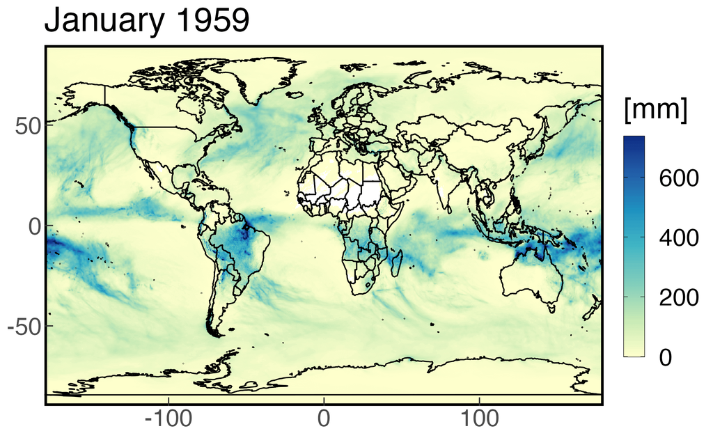

```r
global <- brick("era5_tp_mm_global_195901_202112_025_monthly.nc")
plot_map(global[[1]])
```

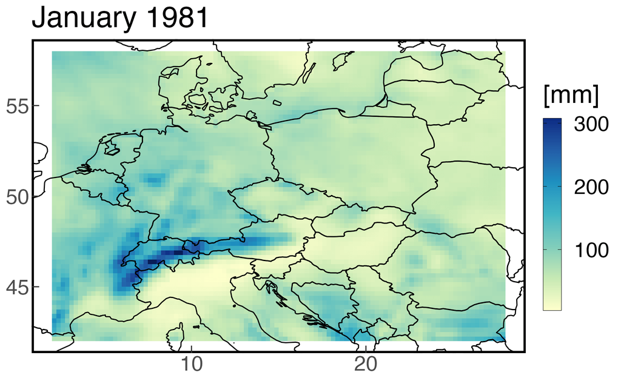

```r
central_europe <- brick("era5_tp_mm_subset_198101_202012_025_monthly.nc")
plot_map(central_europe[[1]])
```

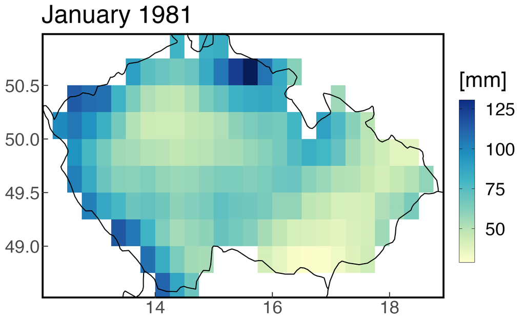

```r
czechia <- brick("era5_tp_mm_cropped_198101_202012_025_monthly.nc")
plot_map(czechia[[1]])
```

### Time Series Visuals

To draw a time series generated by `make_ts`, we use any of the options below, which takes only a `make_ts` “.csv” generated file.

#### Line

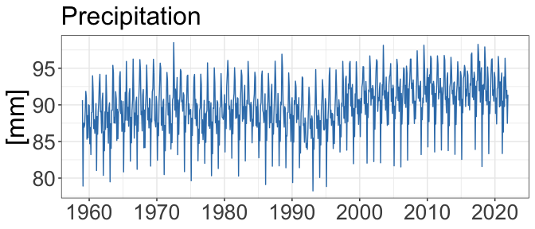

```r
plot_line(era5_global_ts)
```

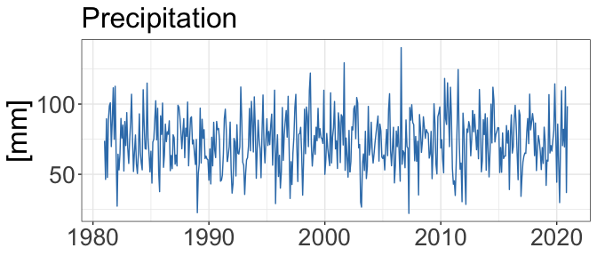

```r
plot_line(era5_ce_ts)
```

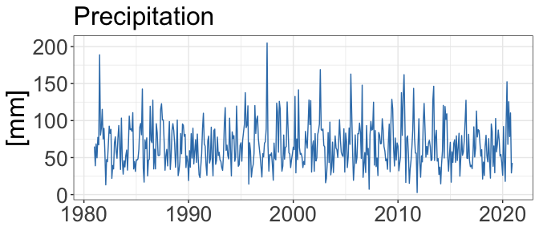

```r
plot_line(era5_cze_ts)
```

#### Heatmap

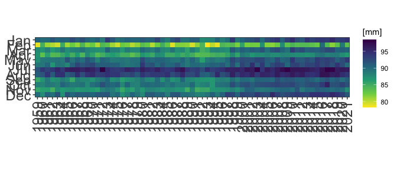

```r
plot_heatmap(era5_global_ts)
```

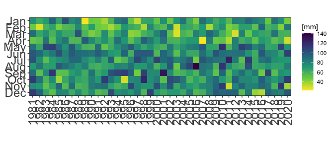

```r
plot_heatmap(era5_ce_ts)
```

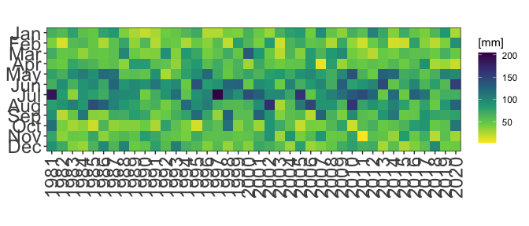

```r
plot_heatmap(era5_cze_ts)
```

#### Boxplot

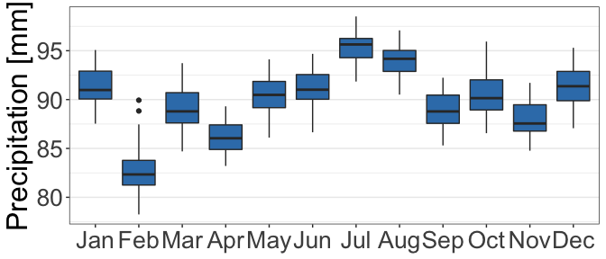

```r
plot_box(era5_global_ts)
```

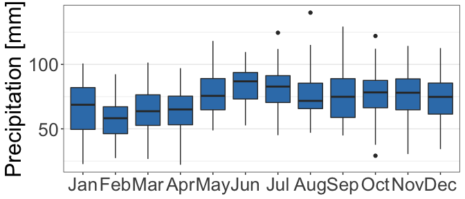

```r
plot_box(era5_ce_ts)
```

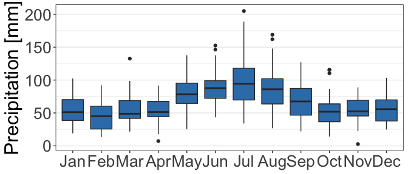

```r
plot_box(era5_cze_ts)
```

#### Density

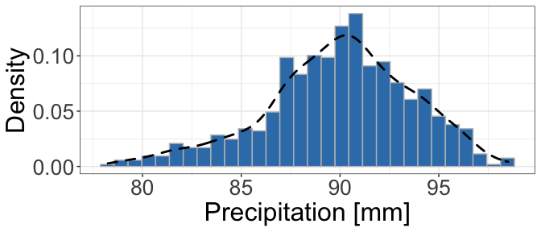

```r
plot_density(era5_global_ts)
```

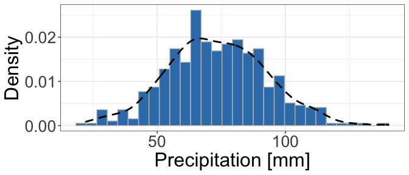

```r
plot_density(era5_ce_ts)
```

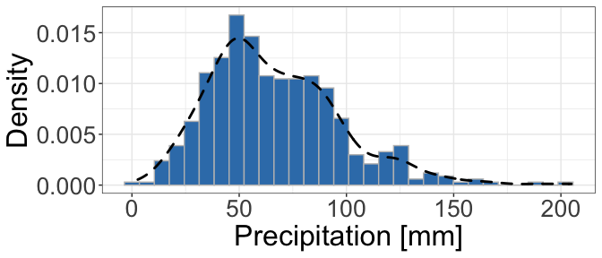

```r
plot_density(era5_cze_ts)
```

#### Summary

**NOTE:** For good aesthetics we recommend saving `plot_summary` with `ggsave(<filename>, <plot>, width = 16.3, height = 15.03)`.

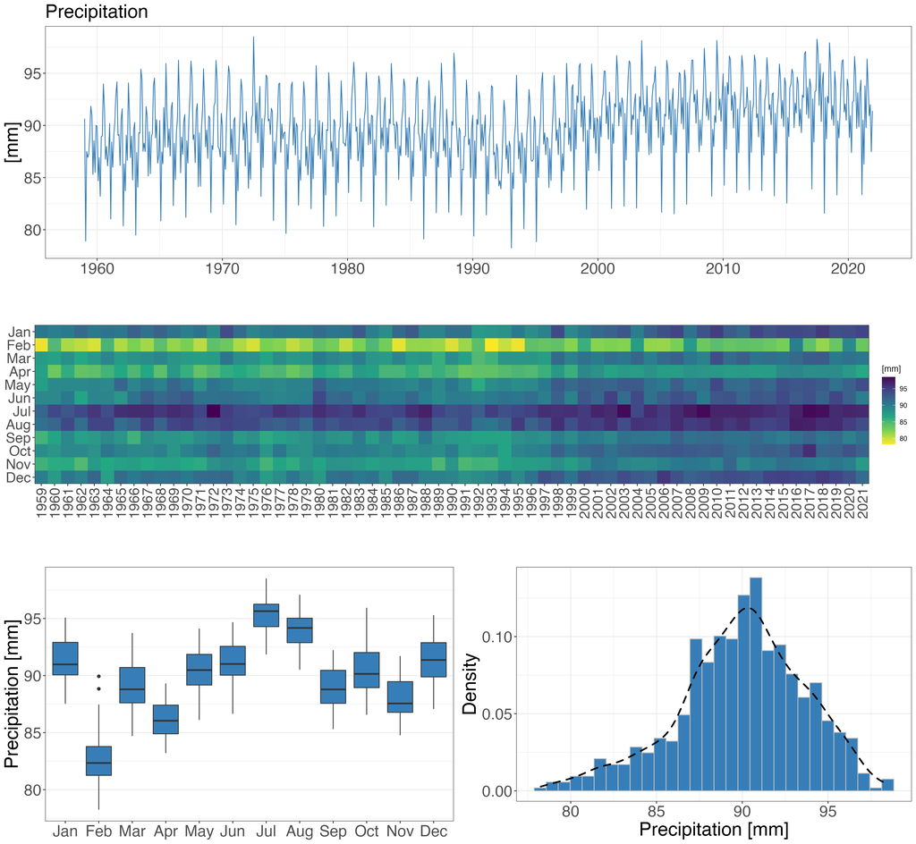

```r
plot_summary(era5_global_ts)
#plot_summary(era5_ce_ts)
#plot_summary(era5_cze_ts)
```

# Coming Soon

More functions for data processing and expanding the database.

# References

Abatzoglou, John T, Solomon Z Dobrowski, Sean A Parks, and Katherine C Hegewisch. 2018. “TerraClimate, a High-Resolution Global Dataset of Monthly Climate and Climatic Water Balance from 1958–2015.” *Scientific Data* 5 (1): 1–12.

Adler, Robert F., George J. Huffman, Alfred Chang, Ralph Ferraro, Ping-Ping Xie, John Janowiak, Bruno Rudolf, Udo Schneider, Scott Curtis, and David Bolvin. 2003. “The Version-2 Global Precipitation Climatology Project (GPCP) Monthly Precipitation Analysis (1979–Present).” *Journal of Hydrometeorology* 4 (6): 1147–67.

Ashouri, Hamed, Kuo-Lin Hsu, Soroosh Sorooshian, Dan K. Braithwaite, Kenneth R. Knapp, L. Dewayne Cecil, Brian R. Nelson, and Olivier P. Prat. 2015. “PERSIANN-CDR: Daily Precipitation Climate Data Record from Multisatellite Observations for Hydrological and Climate Studies.” *Bulletin of the American Meteorological Society* 96 (1): 69–83.

Beck, Hylke E, Eric F Wood, Ming Pan, Colby K Fisher, Diego G Miralles, Albert IJM Van Dijk, Tim R McVicar, and Robert F Adler. 2019. “MSWEP V2 Global 3-Hourly 0.1 Precipitation: Methodology and Quantitative Assessment.” *Bulletin of the American Meteorological Society* 100 (3): 473–500.

Chen, Mingyue, Pingping Xie, John E. Janowiak, and Phillip A. Arkin. 2002. “Global Land Precipitation: A 50-Yr Monthly Analysis Based on Gauge Observations.” *Journal of Hydrometeorology* 3 (3): 249–66.

Funk, Chris, Pete Peterson, Martin Landsfeld, Diego Pedreros, James Verdin, Shraddhanand Shukla, Gregory Husak, et al. 2015. “The Climate Hazards Infrared Precipitation with Stations—a New Environmental Record for Monitoring Extremes.” *Scientific Data* 2 (1): 150066. https://doi.org/10.1038/sdata.2015.66.

Harris, Ian, Timothy J Osborn, Phil Jones, and David Lister. 2020. “Version 4 of the CRU TS Monthly High-Resolution Gridded Multivariate Climate Dataset.” *Scientific Data* 7 (1): 1–18.

Hersbach, Hans, Bill Bell, Paul Berrisford, Shoji Hirahara, András Horányi, Joaquín Muñoz-Sabater, Julien Nicolas, et al. 2020. “The ERA5 Global Reanalysis.” *Quarterly Journal of the Royal Meteorological Society* 146 (730): 1999–2049.

Huffman, G. J., E. F. Stocker, D. T. Bolvin, E. J. Nelkin, and Jackson Tan. 2019. *GPM IMERG Final Precipitation L3 1 Month 0.1 Degree x 0.1 Degree V06, Greenbelt, MD, Goddard Earth Sciences Data and Information Services Center (GES DISC)*.

Huffman, George J, Robert F Adler, David T Bolvin, and Eric J Nelkin. 2010. “The TRMM Multi-Satellite Precipitation Analysis (TMPA).” In *Satellite Rainfall Applications for Surface Hydrology*, 3–22. Springer.

Joyce, Robert J, John E Janowiak, Phillip A Arkin, and Pingping Xie. 2004. “CMORPH: A Method That Produces Global Precipitation Estimates from Passive Microwave and Infrared Data at High Spatial and Temporal Resolution.” *Journal of Hydrometeorology* 5 (3): 487–503.

Kalnay, Eugenia, Masao Kanamitsu, Robert Kistler, William Collins, Dennis Deaven, Lev Gandin, Mark Iredell, Suranjana Saha, Glenn White, and John Woollen. 1996. “The NCEP/NCAR 40-Year Reanalysis Project.” *Bulletin of the American Meteorological Society* 77 (3): 437–72.

Kanamitsu, Masao, Wesley Ebisuzaki, Jack Woollen, Shi-Keng Yang, J. J. Hnilo, M. Fiorino, and G. L. Potter. 2002. “Ncep–Doe Amip-Ii Reanalysis (r-2).” *Bulletin of the American Meteorological Society* 83 (11): 1631–44.

Peterson, Thomas C., and Russell S. Vose. 1997. “An Overview of the Global Historical Climatology Network Temperature Database.” *Bulletin of the American Meteorological Society* 78 (12): 2837–50.

Poli, Paul, Hans Hersbach, Dick P Dee, Paul Berrisford, Adrian J Simmons, Frédéric Vitart, Patrick Laloyaux, et al. 2016. “ERA-20c: An Atmospheric Reanalysis of the Twentieth Century.” *Journal of Climate* 29 (11): 4083–97.

Rodell, Matthew, P. R. Houser, U. E. A. Jambor, J. Gottschalck, K. Mitchell, C.-J. Meng, K. Arsenault, B. Cosgrove, J. Radakovich, and M. Bosilovich. 2004. “The Global Land Data Assimilation System.” *Bulletin of the American Meteorological Society* 85 (3): 381–94.

Schneider, Udo, Andreas Becker, Peter Finger, Anja Meyer-Christoffer, Bruno Rudolf, and Markus Ziese. 2011. “GPCC Full Data Reanalysis Version 6.0 at 0.5: Monthly Land-Surface Precipitation from Rain-Gauges Built on GTS-Based and Historic Data.” *GPCC Data Rep., Doi* 10.

Slivinski, Laura C, Gilbert P Compo, Jeffrey S Whitaker, Prashant D Sardeshmukh, Benjamin S Giese, Chesley McColl, Rob Allan, et al. 2019. “Towards a More Reliable Historical Reanalysis: Improvements for Version 3 of the Twentieth Century Reanalysis System.” *Quarterly Journal of the Royal Meteorological Society* 145 (724): 2876–2908.

Tang, Guoqiang, Martyn P. Clark, and Simon Michael Papalexiou. 2022. “EM-Earth: The Ensemble Meteorological Dataset for Planet Earth.” *Bulletin of the American Meteorological Society* 103 (4): E996–1018. https://doi.org/10.1175/BAMS-D-21-0106.1.

Vargas Godoy, Mijael Rodrigo, Yannis Markonis, Martin Hanel, Jan Kyselỳ, and Simon Michael Papalexiou. 2021. “The Global Water Cycle Budget: A Chronological Review.” *Surveys in Geophysics* 42 (5): 1075–1107.

Willmott, C. J., and K. Matsuura. 2001. *Terrestrial Air Temperature and Precipitation: Monthly and Annual Time Series (1950 - 1999)*.

Xie, P., M. Chen, and W. Shi. 2010. “CPC Global Unified Gauge-Based Analysis of Daily Precipitation.” In *Preprints, 24th Conf. On Hydrology, Atlanta, GA, Amer. Metero. Soc*. Vol. 2.

Xie, Pingping, and Phillip A. Arkin. 1997. “Global Precipitation: A 17-Year Monthly Analysis Based on Gauge Observations, Satellite Estimates, and Numerical Model Outputs.” *Bulletin of the American Meteorological Society* 78 (11): 2539–58.